# All_lectures

## expand with knowledge from https://bradleyboehmke.github.io/HOML/process.html

Re-sampling

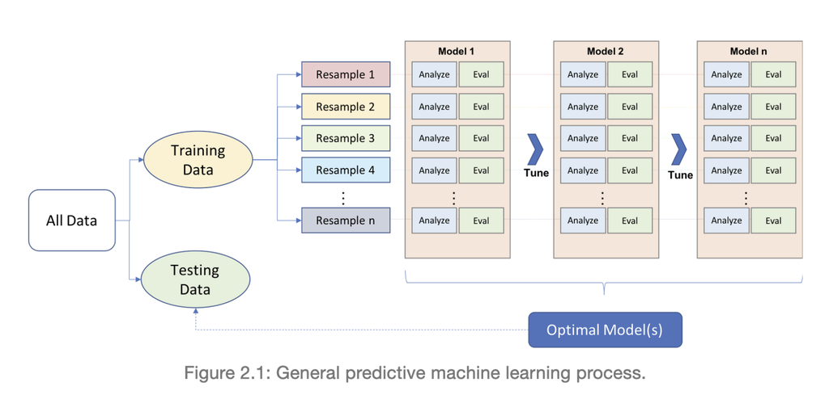

```r
include_graphics("ML process.png")
```

- Single training data leads to inaccurate results. To avoid this we utilize re-sampliung methods

**k-fold cross validation**

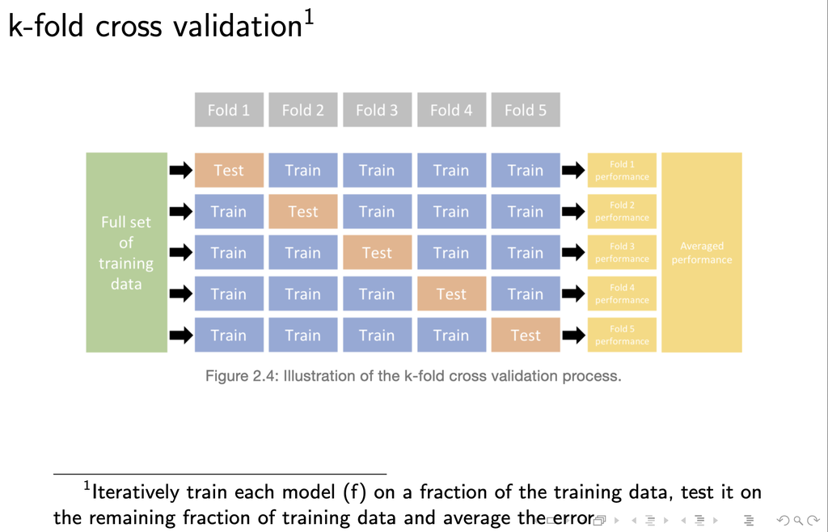

```r
include_graphics("k-fold method.png")
```

**bootstrapping**

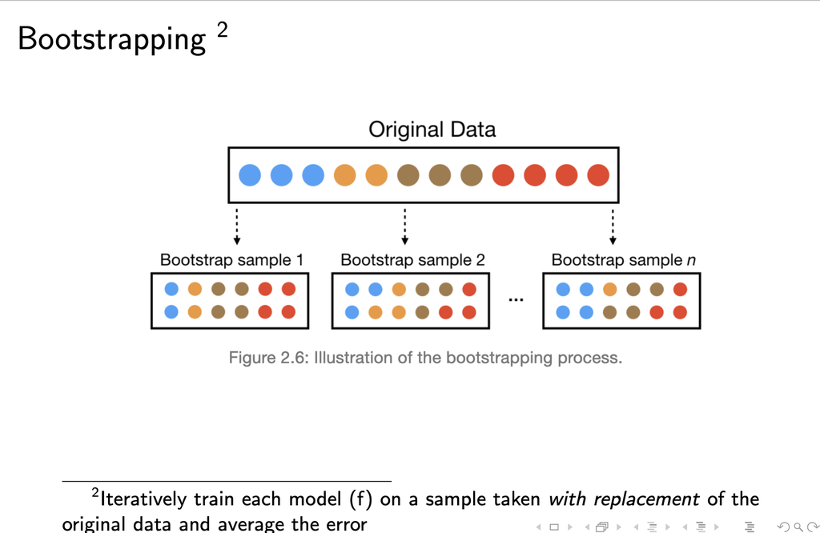

```r
include_graphics("Bootstrapping.png")
```

Use multiple split when practicing to get best results

Knowing this, the standard procedure for model building should be

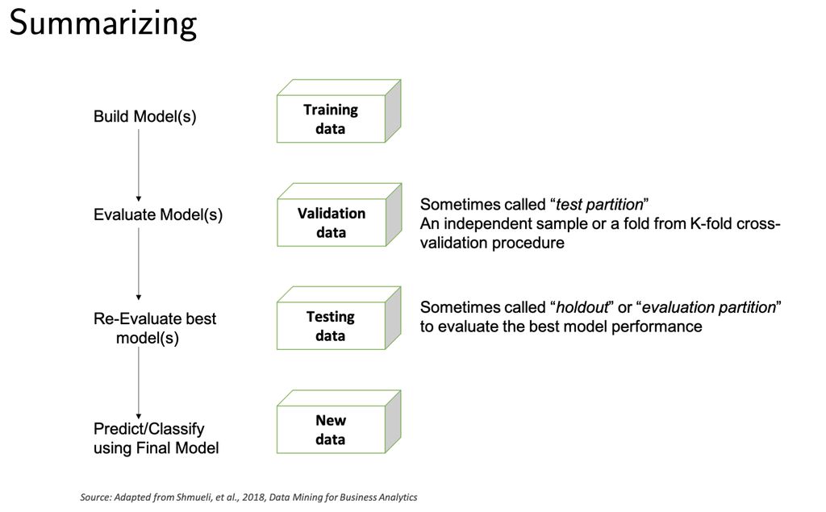

```r
include_graphics("Procedure modelling.png")
```

##Model evaluation criteria ###will be expanded upon

expand with knowledge from https://bradleyboehmke.github.io/HOML/process.html

**Regression models:** - MSE

- RMSE
- Deviance
- MAE
- R-squared

**Classification models**

- Misclassification rate
- Mean per class error
- MSE
- Cross-entropy
- Gini index
- Confusion matric
- Accuracy, Precision, Sensitivity/Recall, Specificity
- ROC and AUC*

## Errors

Training errors(MSE)
$$MSE = \frac{1}{n}
\sum_{i = 1}^{n} (y_i - f̂(x_i))^2$$

Testing error (test MSE)
$$Ave(y_o-f̂(x_o))^2$$
where $x_o,y_o$ are obs. not used to train

##overfitting Small train error

*High test error*

Our model(algorithm) is trying too hard to find a suited fit

*Variance of fit* = Amount by which $f̂$ would change if estimated using different training set

*bias of fit* = error introduced by approximating real-life problem in simple models

*aim to minimize both*

$$E(y_0-f̂(x_o))^2 = Var(f̂(x_o)) +
[bias(f̂(x_o))]^2 + Var(e)$$

where

$E(y_0-f̂(x_o))$ = Expected test MSE

$[bias(f̂(x_o))]$ = Bias of fit

$Var(e)$ = Irreducible error

##Lecture conclusions

Increase in method flexibility (more advanced methods, NN), we can reduce the prediction error (bias). Increasing flexibility does however have diminishing returns and will eventually increase our variance further than reducing our bias.

Machine learning has to one-size-fits-all model, we must utilize all tools and models available to us to treat each dataset independently.

## Lecture 4 coding 🤓

Sample formula interfaces

```r
ames <- AmesHousing::make_ames()
# Sale price as function of neighborhood and year old

lm_lm <- lm(Sale_Price ~Neighborhood + Year_Sold, data = ames)

#lm is used to fit linear models

lm_glm <- glm(Sale_Price ~Neighborhood + Year_Sold, data = ames, family = gaussian)

#glm is used to fit generalized linear models

lm_caret <- train(Sale_Price ~Neighborhood + Year_Sold, data = ames, method = "lm")
lm_caret
```

```
Linear Regression

2930 samples
   2 predictor

No pre-processing
Resampling: Bootstrapped (25 reps)
Summary of sample sizes: 2930, 2930, 2930, 2930, 2930, 2930, ...
Resampling results:

  RMSE      Rsquared   MAE
  52606.52  0.5646596  35649.72

Tuning parameter 'intercept' was held constant at a value of TRUE
```

```r
#train used as part of the Caret library. Documentation found in tfestimators package
```